# Ficha nº 3 - Joel Paula (93392)

OBJETIVO: Verificar experimentalmente qual o Estimador de Máxima Verosimilhança para o parâmetro $\lambda$ de uma Poisson.

No ficheiro .cvs “`amostrasPoisson2`” tem informação sobre três amostras recolhidas de uma população Poisson, da qual desconhece o parâmetro caracterizador. A amostra em am1 é de dimensão 10, am2 e am3 têm, respetivamente, 20 e 30 observações.

# 1. Ler o ficheiro para um dataframe e retirar vetores a1, a2 e a3 correspondentes a cada uma das amostras.

Elimine nestes vetores os valores omissos (NA).

```r
amostras <- read.csv("amostrasPoisson2")
a1 <- na.omit(amostras$am_10)
a2 <- na.omit(amostras$am_20)
a3 <- na.omit(amostras$am_30)

kable(amostras, format = "pipe")
```

| am_10 | am_20 | am_30 |
| --- | --- | --- |
| 4 | 5 | 4 |
| 0 | 3 | 3 |
| 3 | 2 | 6 |
| 3 | 8 | 5 |
| 6 | 3 | 4 |
| 3 | 4 | 8 |
| 5 | 8 | 4 |
| 7 | 4 | 4 |
| 8 | 8 | 3 |
| 1 | 5 | 0 |
| NA | 5 | 7 |
| NA | 10 | 3 |
| NA | 4 | 4 |
| NA | 4 | 2 |
| NA | 5 | 7 |
| NA | 6 | 1 |
| NA | 4 | 7 |
| NA | 6 | 7 |
| NA | 4 | 5 |
| NA | 4 | 4 |
| NA | NA | 3 |
| NA | NA | 5 |
| NA | NA | 7 |
| NA | NA | 6 |
| NA | NA | 6 |
| NA | NA | 3 |
| NA | NA | 2 |
| NA | NA | 2 |
| NA | NA | 7 |
| NA | NA | 5 |

# 2. Para cada amostra, calcular as medidas básicas caracterizadoras

(média, desvio-padrão, variância, mínimo e máximo)

| Amostra | média | mínimo | máximo | desvio padrão | Variância |
| --- | --- | --- | --- | --- | --- |
| a1 | 4 | 0 | 8 | 2.538591 | 6.4444444 |
| a2 | 5.1 | 2 | 10 | 2.0235456 | 4.0947368 |
| a3 | 4.4666667 | 0 | 8 | 2.0465839 | 4.1885057 |

# 3. Apresente gráficos de cada uma das respetivas funções de probabilidade empíricas

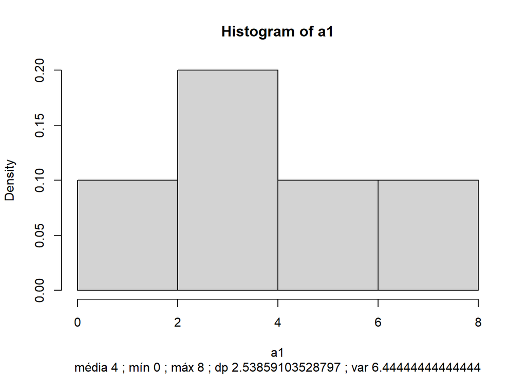

```r
# a1
hist(a1, freq = FALSE, sub=paste("média", mean(a1), "; mín", min(a1), "; máx", max(a1), "; dp",sd(a1), "; var", var(a1)))
```

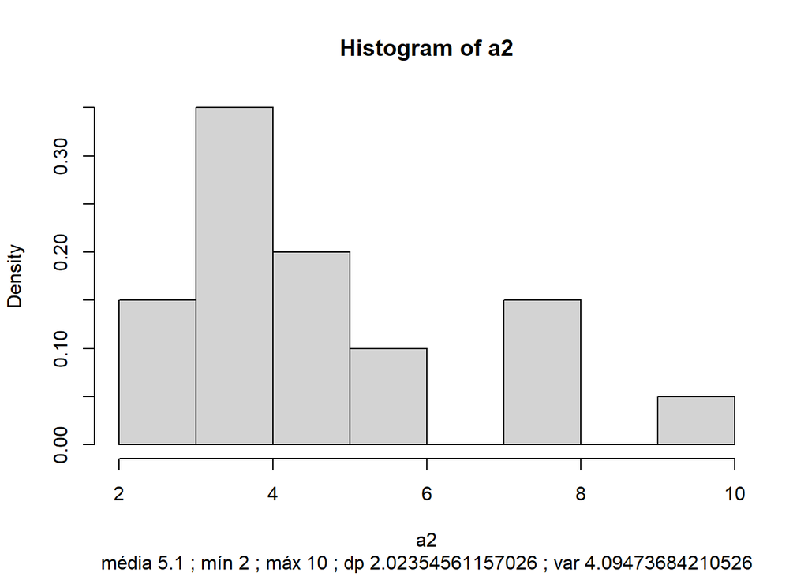

```r
# a2
hist(a2, freq = FALSE, sub=paste("média", mean(a2), "; mín", min(a2), "; máx", max(a2), "; dp",sd(a2), "; var", var(a2)))
```

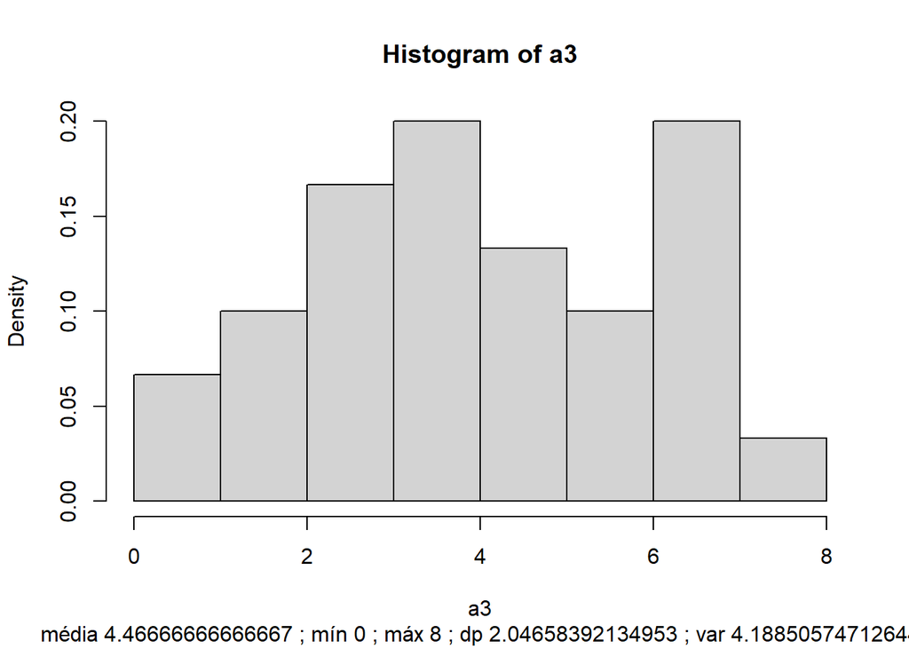

```r
# a3
hist(a3, freq = FALSE, sub=paste("média", mean(a3), "; mín", min(a3), "; máx", max(a3), "; dp",sd(a3), "; var", var(a3)))
```

# 4. Apresente a dedução – analítica – da função de verosimilhança

para o parâmetro $λ$ de uma Poisson, com base numa amostra genérica de tamanho $n$.

Genéricamente, a função de verosimilhança é:
$$\mathcal{L}(\theta) = \prod_{i=1}^n f(x_i \mid \theta)$$
A função de distribuição de Poisson é:
$$\mathcal{f}(x) = \frac{e^{-\lambda} \lambda^{ x}}{x!}$$
Sendo que $E[X] = \lambda$ e $Var[X] = \lambda$.

Então a nossa incógnita é $\lambda$ e deduzindo a função de verosimilhança é:
$$\mathcal{L}(\lambda) = \frac{e^{-n\lambda} \lambda^{\sum_{i=1}^{n} x_i}}{\displaystyle\prod_{i=1}^{n} x_i!}$$

# 5. O que se pretende é maximizar a função definida

pelo que se utilizará a função optimize do R (veja help(optimize) no R). Obtenha então o ótimo para cada uma das três amostras disponíveis.

```r
# a função a otimizar
ff <- function(lambda, x){
  (exp(-length(x)*lambda)*lambda^(sum(x)))/prod(factorial(x))
}
optimize(ff, c(0,10), maximum = TRUE, x=a1)
```

```
## $maximum
## [1] 3.999999
##
## $objective
## [1] 5.642747e-11
```

```r
optimize(ff, c(0,10), maximum = TRUE, x=a2)
```

```
## $maximum
## [1] 5.099991
##
## $objective
## [1] 8.863292e-19
```

```r
optimize(ff, c(0,10), maximum = TRUE, x=a3)
```

```
## $maximum
## [1] 4.466666
##
## $objective
## [1] 1.313392e-28
```

# 6. Compare os resultados obtidos nas otimizações acima com as medidas básicas obtidas em 3.

O que observa/conclui?

verifico que o máximo $\lambda$ encontrado corresponde sempre ao valor da média da amostra, pelo que parece ser um bom estimador.

# 7. Usando as técnicas analíticas tradicionais de procura de extremos de uma função real de variável real, determine o estimador de máxima verosimilhança para o parâmetro $\lambda$ de uma Poisson.

Para nos ajudar na derivação que é necessária para os cálculos que se seguem, vamos usar a função logaritmo da nossa função de verosimilhança, que tem um comportamento análogo ao da função:
$$\ln (\mathcal{L}(\lambda)) = \ln(e^{-n\lambda} \lambda^{\sum_{i=1}^{n} x_i}) - \ln(\displaystyle\prod_{i=1}^{n} x_i!) =$$
$$= \ln(e^{-n\lambda}) + \ln( \lambda^{\sum_{i=1}^{n} x_i}) - \ln(\displaystyle\prod_{i=1}^{n} x_i!) =$$
$$= {-n\lambda} \times \ln(e) + {\sum_{i=1}^{n} x_i} \times \ln( \lambda) - \ln(\displaystyle\prod_{i=1}^{n} x_i!) =$$
$$= {-n\lambda} + {\sum_{i=1}^{n} x_i} \times \ln( \lambda) - \ln(\displaystyle\prod_{i=1}^{n} x_i!)$$

derivando:
$$\frac{d \ln(\mathcal{L}(\lambda))}{d\lambda} = -n + \frac{1}{\lambda}{\sum_{i=1}^{n} x_i}$$

Igualando o resultado a zero:
$$\frac{d \ln(\mathcal{L}(\lambda))}{d\lambda} = 0 \Leftrightarrow -n + \frac{1}{\lambda}{\sum_{i=1}^{n} x_i} = 0 \Leftrightarrow$$
$$\Leftrightarrow \lambda = \frac{{\sum_{i=1}^{n} x_i}}{n} = \bar{X}$$

Portanto, o estimador de $\lambda$ é:
$$\hat\lambda = \bar{X}$$

Vamos confirmar se o estimador é realmente um ponto máximo, fazendo a segunda derivada da função:
$$\frac{d^2 \ln(\mathcal{L}(\lambda))}{d\lambda^2} = -\frac{1}{\lambda^2}{\sum_{i=1}^{n} x_i} <0$$
Portanto o nosso estimador é o ponto máximo da função de verosimilhança, então temos que $\hat\lambda_{MV}=\frac{{\sum_{i=1}^{n} x_i}}{n} = \bar{X}$